# title: **“S5 Contaminantes del aire en India”**

# Índice

1. Introducción
2. Objetivos
3. Marco teórico
4. Descriptores numéricos y gráficos
5. Planificación

## 1. Introducción

### Justificación

¿Por qué realizar un estudio sobre este tema?

En los últimos años el calentamiento global ha ido incrementando por diversos factores, uno de ellos son los gases contaminantes, que no solo perjudican a la naturaleza sino a los seres humanos ya que la calidad del aire debe ser controlada. En ese sentido, utilizaremos distintas bases de datos de India sobre las ciudades más pobladas respecto a la producción de gases contaminantes por ciudades, días, horas y estaciones, a partir del año 2014 a 2020. A partir de ello, se busca analizar el incremento de la producción de gases respecto a los años, determinar los horarios o días en que se produce mayor producción de gases contaminantes, así como determinar la cantidad de gases producidos por años y poder compararlo con los estándares permitidos por la OMS, de esa manera predecir el año en el cual se superaría los dichos estándares entre muchas otros. Estos resultados nos brindan un panorama claro del incremento de la producción de CO2, NO2, NHx, NH3, SO2 en uno de los países con gran población.

### Importancia

Controlar la calidad del aire es de vital importancia, en vista a que sí existen una gran cantidad de contaminantes puede afectar gravemente a los seres humanos y al medio ambiente, con el paso de los años la industrialización se ha ido expandiendo a gran escala lo cual a su vez genera una gran producción de gases que ha ido incrementando. En ese sentido es necesario conocer y controlar dichas producciones, con lo cual podemos considerar si el aire está contaminado según ciertos estándares internacionales o identificar el incremento anual que se produce, en caso resulte ser un cambio muy grande se pueden producir problemas en los próximos años, pero conociendo los valores se puede tomar medidas para poder reducir la producción de gases, así como el impacto negativo.

### Factibilidad

Es factible porque trabajamos con distintos data frames los cuales están sistematizados por ciudades y las variables muestran la cantidad de producción de distintos gases respecto a las fechas (día, mes y año), horas y estaciones, lo que proporciona una gran cantidad de información para cumplir con los objetivos escritos a continuación.

### Objetivos:

- Determinar la variación de producción de gases contaminantes respecto a los años y/o ciudades para poder interpretar futuros valores y poder determinar si la calidad del aire cumple con los parámetros internacionales. -> O.P.
- Determinar los horarios donde se producen más contaminantes respecto a las ciudades. Tabular y analizar el AQI (Índice de calidad del aire) diario de la ciudad de Delhi en los años 2019 y 2020.
- Tabular y analizar AQI bucket definido como “muy pobre” y “satisfactorio” para reconocer posibles impactos en la salud de los habitantes de las ciudades en estudio.
- Tabular y analizar AQI bucket definido como “muy pobre” y “satisfactorio” para reconocer posibles impactos en la salud de los habitantes respecto a los meses.

### Preguntas:

1. ¿Cuáles son los AQI bucket mensuales más recurrentes en la ciudad de Delhi en los años 2019 y 2020? (mosaico)
2. ¿Qué horas no son recomendables debido a la cantidad de gases contaminantes según el AQI (Índice de calidad del aire) diario de la ciudad de Delhi (capital de India)?
3. ¿Cuáles son las horas donde se producen más gases contaminantes respecto a cada ciudad entre los años 2015 - 2020?
4. ¿Qué ciudades producen más gases contaminantes en los años 2015-2020?
5. ¿Cuál es la ciudad con mayor AQI por años (2015-2020)?
6. ¿Cuál es el contaminante más presente entre los años 2019 y 2020?

```r
#install.packages("timevis")

library("readr")
library("dplyr")
library("stringr")
library("modeest")
library("timevis")
CH<-read_csv("city_hour.csv")
```

#Arreglando CH

```r
library(readr)
city_hour <- read_csv("city_hour.csv",
    col_types = cols(PM2.5 = col_double(),
        PM10 = col_double(), NH3 = col_double(),
        AQI = col_double(), AQI_Bucket = col_character(),Year= col_double()))
```

```r
CH1<-city_hour %>% filter(complete.cases(.))
```

## 3. Marco Teórico

| AQI | Remark | Color de código | Posible impacto a la salud |
| --- | --- | --- | --- |
| 0-50 | Bueno | Verde | Impacto mínimo |
| 51-100 | Satisfactorio | Verde claro | Molestias respiratorias leves para personas sensibles |
| 101-200 | Moderado | Amarillo | Molestias respiratorias para las personas con enfermedades pulmonares, asma y cardíacas. |
| 201-300 | Pobre | Naranja | Incomodidad respiratoria para la mayoría de las personas con exposición prolongada. |
| 301-400 | Muy pobre | Rojo | Molestias respiratorias para las personas con enfermedades pulmonares, asma y cardíacas. |
| 401-500 | Severo | Rojo oscuro | Afecta a las personas sanas y afecta gravemente a quienes padecen enfermedades existentes. |

*Tabla adaptada de:https://app.cpcbccr.com/AQI_India/

### Población

Componentes del aire en ciudades de India

### Muestra

Muestras de aire en las ciudades de: Amaravati, Amritsar, Chandigarh, Delhí, Gurugram, Hyderabad, Kolkata, Patna, Visakhapatnam

### Tipo de muestreo

Muestreo aleatorio sin reemplazo

## Variables

Tabla: Significado de las variables

[output not shown]

| **Variables** | **Tipo de variable** | **Nivel de medición** |
| --- | --- | --- |
| *city* | cualitativa | nominal |
| *hour* | cualitativa | ordinal |
| *day* | cualitativa | ordinal |
| *month* | cualitativa | nominal |
| *year* | cualitativa | ordinal |
| *PM10* | cuantitativa continua | razón |
| *PM2.5* | cuantitativa continua | razón |
| *NO* | cuantitativa continua | razón |
| *NO2* | cuantitativa continua | razón |
| *NH3* | cuantitativa continua | razón |
| *C_O* | cuantitativa continua | razón |
| *SO2* | cuantitativa continua | razón |
| *O3* | cuantitativa continua | razón |
| *Benzene* | cuantitativa continua | razón |
| *Toluene* | cuantitativa continua | razón |
| *Xylene* | cuantitativa continua | razón |
| *AQI* | cuantitativa continua | razón |
| *AQI_Bucket* | cualitativa | ordinal |

### Limpieza de datos

| **Variable** | **¿Por qué no es relevante?** |
| --- | --- |
| *NOx* | Porque no hay unidades exactas de los datos de los distintos óxidos de nitrógeno en el aire tomados por las estaciones |

Eliminación de variables:

```r
sum(complete.cases(DFCH1))
```

```
## [1] 129277
```

```r
sum(is.na(DFCH1))
```

```
## [1] 0
```

```r
DFCH1<- DFCH1 %>% select(-NOx)
```

## 4. Descriptores numéricos y gráficos

### Descriptores numéricos

#### Variable: NO

```r
round(mean(DFCH1$NO, na.rm=1),2)
```

```
## [1] 18.11
```

```r
round(median(DFCH1$NO, na.rm=1),2)
```

```
## [1] 8.24
```

```r
round(mfv(DFCH1$NO, na_rm=1),2)
```

```
## [1] 1.7
```

```r
round(range(DFCH1$NO, na.rm=1),2)
```

```
## [1]   0.01 419.78
```

```r
round(var(DFCH1$NO, na.rm=1),2)
```

```
## [1] 840.17
```

```r
round(sd(DFCH1$NO, na.rm=1),2)
```

```
## [1] 28.99
```

```r
round(IQR(DFCH1$NO, na.rm=1),2)
```

```
## [1] 14.26
```

#### Variable: NO2

```r
round(mean(DFCH1$NO2, na.rm=1),2)
```

```
## [1] 32.82
```

```r
round(median(DFCH1$NO2, na.rm=1),2)
```

```
## [1] 27.2
```

```r
round(mfv(DFCH1$NO2, na_rm=1),2)
```

```
## [1] 9.19
```

```r
round(range(DFCH1$NO2, na.rm=1),2)
```

```
## [1]   0.10 266.73
```

```r
round(var(DFCH1$NO2, na.rm=1),2)
```

```
## [1] 530.66
```

```r
round(sd(DFCH1$NO2, na.rm=1),2)
```

```
## [1] 23.04
```

```r
round(IQR(DFCH1$NO2, na.rm=1),2)
```

```
## [1] 28.68
```

#### Variable: C_O

```r
round(mean(DFCH1$C_O, na.rm=1),2)
```

```
## [1] 1030.95
```

```r
round(median(DFCH1$C_O, na.rm=1),2)
```

```
## [1] 700
```

```r
round(mfv(DFCH1$C_O, na_rm=1),2)
```

```
## [1] 0
```

```r
round(range(DFCH1$C_O, na.rm=1),2)
```

```
## [1]     0 31620
```

```r
round(var(DFCH1$C_O, na.rm=1),2)
```

```
## [1] 2473117
```

```r
round(sd(DFCH1$C_O, na.rm=1),2)
```

```
## [1] 1572.61
```

```r
round(IQR(DFCH1$C_O, na.rm=1),2)
```

```
## [1] 640
```

#### Variable: SO2

```r
round(mean(DFCH1$SO2, na.rm=1),2)
```

```
## [1] 11.28
```

```r
round(median(DFCH1$SO2, na.rm=1),2)
```

```
## [1] 8.83
```

```r
round(mfv(DFCH1$SO2, na_rm=1),2)
```

```
## [1] 5.5
```

```r
round(range(DFCH1$SO2, na.rm=1),2)
```

```
## [1]   0.01 199.93
```

```r
round(var(DFCH1$SO2, na.rm=1),2)
```

```
## [1] 107.2
```

```r
round(sd(DFCH1$SO2, na.rm=1),2)
```

```
## [1] 10.35
```

```r
round(IQR(DFCH1$SO2, na.rm=1),2)
```

```
## [1] 8.1
```

#### Variable: O3

```r
round(mean(DFCH1$O3, na.rm=1),2)
```

```
## [1] 36.35
```

```r
round(median(DFCH1$O3, na.rm=1),2)
```

```
## [1] 28.22
```

```r
round(mfv(DFCH1$O3, na_rm=1),2)
```

```
## [1] 22.14
```

```r
round(range(DFCH1$O3, na.rm=1),2)
```

```
## [1]   0.02 219.78
```

```r
round(var(DFCH1$O3, na.rm=1),2)
```

```
## [1] 766.6
```

```r
round(sd(DFCH1$O3, na.rm=1),2)
```

```
## [1] 27.69
```

```r
round(IQR(DFCH1$O3, na.rm=1),2)
```

```
## [1] 31.83
```

#### Variable: Benzene

```r
round(mean(DFCH1$Benzene, na.rm=1),2)
```

```
## [1] 3.91
```

```r
round(median(DFCH1$Benzene, na.rm=1),2)
```

```
## [1] 2.25
```

```r
round(mfv(DFCH1$Benzene, na_rm=1),2)
```

```
## [1] 0
```

```r
round(range(DFCH1$Benzene, na.rm=1),2)
```

```
## [1]   0.00 120.08
```

```r
round(var(DFCH1$Benzene, na.rm=1),2)
```

```
## [1] 34.32
```

```r
round(sd(DFCH1$Benzene, na.rm=1),2)
```

```
## [1] 5.86
```

```r
round(IQR(DFCH1$Benzene, na.rm=1),2)
```

```
## [1] 3.62
```

#### Variable: Toluene

```r
round(mean(DFCH1$Toluene, na.rm=1),2)
```

```
## [1] 11.34
```

```r
round(median(DFCH1$Toluene, na.rm=1),2)
```

```
## [1] 6.2
```

```r
round(mfv(DFCH1$Toluene, na_rm=1),2)
```

```
## [1] 1.1
```

```r
round(range(DFCH1$Toluene, na.rm=1),2)
```

```
## [1]   0.00 198.05
```

```r
round(var(DFCH1$Toluene, na.rm=1),2)
```

```
## [1] 226.27
```

```r
round(sd(DFCH1$Toluene, na.rm=1),2)
```

```
## [1] 15.04
```

```r
round(IQR(DFCH1$Toluene, na.rm=1),2)
```

```
## [1] 11.59
```

#### Variable: Xylene

```r
round(mean(DFCH1$Xylene, na.rm=1),2)
```

```
## [1] 2.57
```

```r
round(median(DFCH1$Xylene, na.rm=1),2)
```

```
## [1] 1
```

```r
round(mfv(DFCH1$Xylene, na_rm=1),2)
```

```
## [1] 0
```

```r
round(range(DFCH1$Xylene, na.rm=1),2)
```

```
## [1]   0.00 261.95
```

```r
round(var(DFCH1$Xylene, na.rm=1),2)
```

```
## [1] 28.58
```

```r
round(sd(DFCH1$Xylene, na.rm=1),2)
```

```
## [1] 5.35
```

```r
round(IQR(DFCH1$Xylene, na.rm=1),2)
```

```
## [1] 2.47
```

#### Variable: PM2.5

```r
round(mean(DFCH1$PM2.5, na.rm=1),2)
```

```
## [1] 63.92
```

```r
round(median(DFCH1$PM2.5, na.rm=1),2)
```

```
## [1] 47.5
```

```r
round(mfv(DFCH1$PM2.5, na_rm=1),2)
```

```
## [1] 56
```

```r
round(range(DFCH1$PM2.5, na.rm=1),2)
```

```
## [1]   0.03 999.99
```

```r
round(var(DFCH1$PM2.5, na.rm=1),2)
```

```
## [1] 3862.94
```

```r
round(sd(DFCH1$PM2.5, na.rm=1),2)
```

```
## [1] 62.15
```

```r
round(IQR(DFCH1$PM2.5, na.rm=1),2)
```

```
## [1] 49.5
```

#### Variable: PM10

```r
round(mean(DFCH1$PM10, na.rm=1),2)
```

```
## [1] 128.28
```

```r
round(median(DFCH1$PM10, na.rm=1),2)
```

```
## [1] 101.5
```

```r
round(mfv(DFCH1$PM10, na_rm=1),2)
```

```
## [1] 94
```

```r
round(range(DFCH1$PM10, na.rm=1),2)
```

```
## [1]    1 1000
```

```r
round(var(DFCH1$PM10, na.rm=1),2)
```

```
## [1] 9876.02
```

```r
round(sd(DFCH1$PM10, na.rm=1),2)
```

```
## [1] 99.38
```

```r
round(IQR(DFCH1$PM10, na.rm=1),2)
```

```
## [1] 93.65
```

### Descriptores gráficos

```r
#Suma total de contaminantes por fila
DFCH1<-DFCH1 %>% mutate(ST = NO+NO2+NH3+C_O+SO2+O3+Benzene+Toluene+Xylene)
```

Observación: Nuestras 4 graficas muestran los mismos incrementos y decrementos de contaminantes entre los años 2017 - 2020. Hipótesis: A partir de las 18:00 horas se nota un incremento en la cantidad de sustancias contaminantes debido a que las horas de estudio de la población culminan a las 3 pm, coincidiendo con un rango de dos horas dedicado al tiempo libre para luego dedicarse a los propios negocios de cada persona. Pues el 70% a 80% del mercado pertenece al sector informal y solo el 20% al sector formal. Lo que implica un consumo independiente de recursos que generan más contaminantes diarios y por horas. Asimismo, este incremento se mantiene durante horas de la madrugada entre las 0 - 5 am. Horas donde la mayoría de las industrias emiten sus gases contaminantes al exterior aprovechando que la población está dormida para causar el menor impacto sanitario posible.

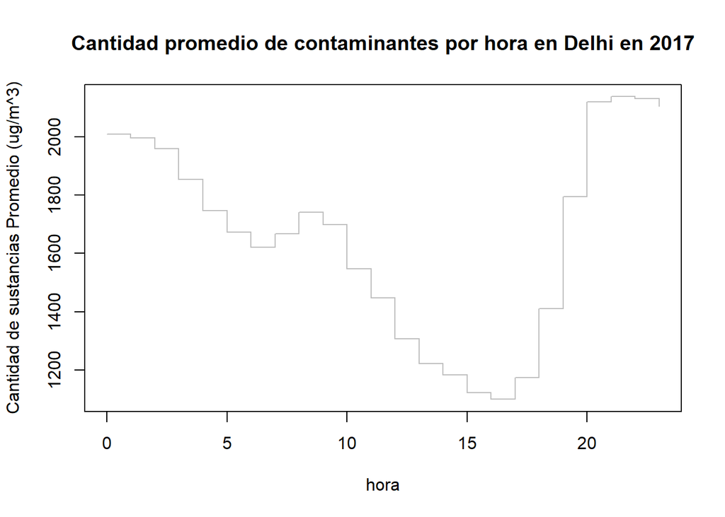

```r
DH<- DFCH1%>%filter(City=="Delhi")

#AÑO 2017
DH17<-DH%>% filter(Year==2017)%>% group_by(Time) %>% summarise(prom_sust=mean(ST))
plot(DH17$Time, DH17$prom_sust,xlab="hora",ylab="Cantidad de sustancias Promedio (ug/m^3)",col="grey",type="s",main="Cantidad promedio de contaminantes por hora en Delhi en 2017")
```

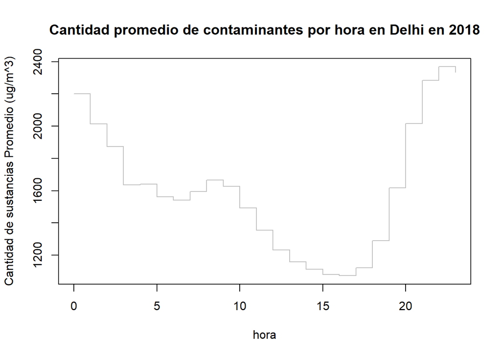

```r
#AÑO 2018
DH18<-DH%>% filter(Year==2018)%>% group_by(Time) %>% summarise(prom_sust=mean(ST))
plot(DH18$Time, DH18$prom_sust,xlab="hora",ylab="Cantidad de sustancias Promedio (ug/m^3)",col="grey",type="s",main="Cantidad promedio de contaminantes por hora en Delhi en 2018")
```

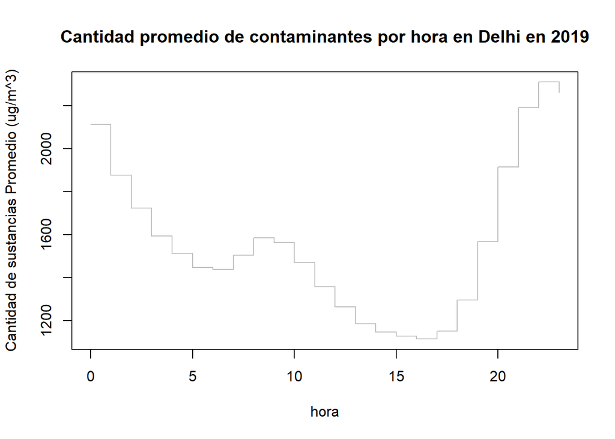

```r
#AÑO 2019
DH19<-DH%>% filter(Year==2019)%>% group_by(Time) %>% summarise(prom_sust=mean(ST))
plot(DH19$Time, DH19$prom_sust,xlab="hora",ylab="Cantidad de sustancias Promedio (ug/m^3)",col="grey",type="s",main="Cantidad promedio de contaminantes por hora en Delhi en 2019")
```

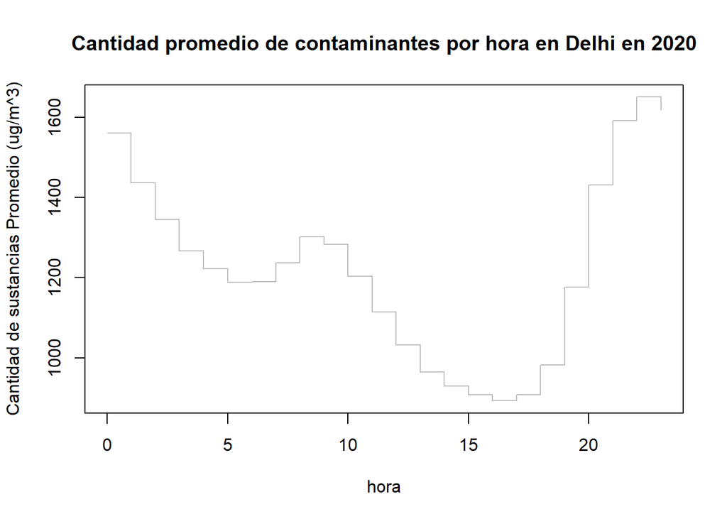

```r
#AÑO 2020
DH20<-DH%>% filter(Year==2020)%>% group_by(Time) %>% summarise(prom_sust=mean(ST))
plot(DH20$Time, DH20$prom_sust,xlab="hora",ylab="Cantidad de sustancias Promedio (ug/m^3)",col="grey",type="s",main="Cantidad promedio de contaminantes por hora en Delhi en 2020")
```

```r
C_T <- DFCH1 %>% group_by(Year) %>% summarise(City,ST)
#2017
C_T_2017 <- C_T %>% filter(Year==2017)
C_T_2017 <- C_T_2017 %>% group_by(City) %>% summarise(mean(ST))
C_T_2017 <- C_T_2017 %>% rename("MeanST"="mean(ST)")


#2018
C_T_2018 <- C_T %>% filter(Year==2018)
C_T_2018 <- C_T_2018 %>% group_by(City) %>% summarise(mean(ST))
C_T_2018 <- C_T_2018 %>% rename("MeanST"="mean(ST)")


#2019
C_T_2019 <- C_T %>% filter(Year==2019,City==c("Amaravati","Amritsar","Delhi","Hyderabad","Visakhapatnam"))
C_T_2019 <- C_T_2019 %>% group_by(City) %>% summarise(mean(ST))
C_T_2019 <- C_T_2019 %>% rename("MeanST"="mean(ST)")



#2020

C_T_2020 <- C_T %>% filter(Year==2020,City==c("Amaravati","Amritsar","Delhi","Hyderabad","Visakhapatnam"))
```

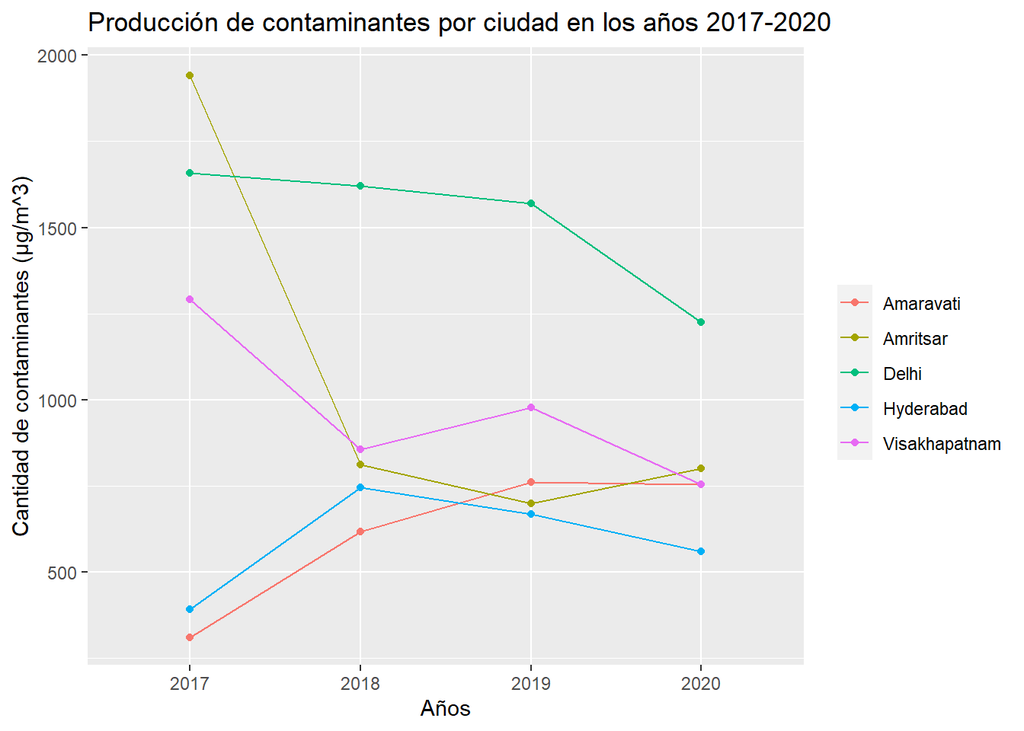

```r
C_T_2020 <- C_T_2020 %>% group_by(City) %>% summarise(mean(ST))
C_T_2020 <- C_T_2020 %>% rename("MeanST"="mean(ST)")


Anios<-c("2017","2018","2019","2020")
Amaravati<-c(C_T_2017$MeanST[1],C_T_2018$MeanST[1],C_T_2019$MeanST[1],C_T_2020$MeanST[1])
Amritsar<-c(C_T_2017$MeanST[2],C_T_2018$MeanST[2],C_T_2019$MeanST[2],C_T_2020$MeanST[2])
Delhi<-c(C_T_2017$MeanST[3],C_T_2018$MeanST[3],C_T_2019$MeanST[3],C_T_2020$MeanST[3])
Hyderabad<-c(C_T_2017$MeanST[4],C_T_2018$MeanST[4],C_T_2019$MeanST[4],C_T_2020$MeanST[4])
Visakhapatnam<-c(C_T_2017$MeanST[5],C_T_2018$MeanST[5],C_T_2019$MeanST[5],C_T_2020$MeanST[5])

Ciudades<-c(Amaravati,Amritsar,Delhi,Hyderabad,Visakhapatnam)
CxA<-data.frame(Anios, Amaravati,Amritsar,Delhi,Hyderabad,Visakhapatnam)
library(ggplot2)
ggplot(data=CxA,mapping = aes(x=Anios))+geom_line(data=CxA,mapping = aes(y=Amaravati,color="Amaravati"),group=1)+geom_point(mapping = aes(y=Amaravati,color="Amaravati"))+geom_line(mapping = aes(y=Amritsar,color="Amritsar"),group=1)+geom_point(mapping = aes(y=Amritsar,color="Amritsar"))+geom_line(mapping = aes(y=Delhi,color="Delhi"),group=1)+geom_point(mapping = aes(y=Delhi,color="Delhi"))+geom_line(mapping = aes(y=Hyderabad,color="Hyderabad"),group=1)+geom_point(mapping = aes(y=Hyderabad,color="Hyderabad"))+geom_line(mapping = aes(y=Visakhapatnam,color="Visakhapatnam"),group=1)+geom_point(mapping = aes(y=Visakhapatnam,color="Visakhapatnam"))+ggtitle("Producción de contaminantes por ciudad en los años 2017-2020") +
    labs(y= "Cantidad de contaminantes (µg/m^3)", x="Años", color="")
```

##### Ciudad con mayor cantidad de contaminantes respecto a los años

Observación: Se puede reconocer que la ciudad de Delhi es la ciudad que tiene los mayores valores de contaminantes a lo largo de los años. De los 4 años en estudio 3 tienen a Delhi como la ciudad que emite más contaminantes en promedio.

Hipótesis: La capital de India tiene una población estimada de 20 758 501. Si comparamos la población de esta ciudad con el resto de ciudades de India, se puede ver que es la ciudad más poblada y con mayor densidad poblacional de India. Esto se relaciona con los valores elevados de gases, pues debido a la concentración de población la cantidad de gases aumenta.

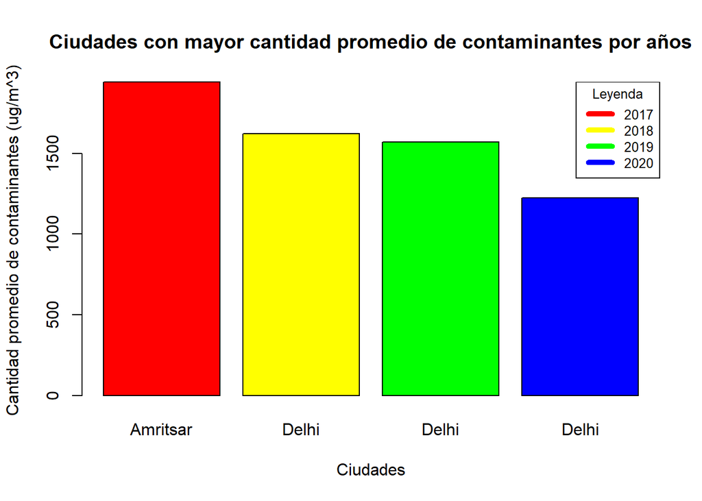

```r
Cmax2017<-C_T_2017[which.max(C_T_2017$MeanST),]
Cmax2018<-C_T_2018[which.max(C_T_2018$MeanST),]
Cmax2019<-C_T_2019[which.max(C_T_2019$MeanST),]
Cmax2020<-C_T_2020[which.max(C_T_2020$MeanST),]

Ciudades<-c("Amritsar","Delhi","Delhi","Delhi")
Cantidades<-c(Cmax2017$MeanST,Cmax2018$MeanST,Cmax2019$MeanST,Cmax2020$MeanST)

CxC<-data.frame(Ciudades,Cantidades)

barplot(CxC$Cantidades,names.arg =CxC$Ciudades,main="Ciudades con mayor cantidad promedio de contaminantes por años",xlab="Ciudades",ylab="Cantidad promedio de contaminantes (ug/m^3)",col=c("red","yellow","green","blue"))

legend(x = "topright", legend = c("2017","2018","2019","2020"), title = "Leyenda",col=c("red","yellow","green","blue"),lwd = 5,cex=0.8)
```

Hipótesis: A partir del 2015 se tomaron medidas para la contaminación del aire en India porque en los años pasados, según la OMS, era uno de los lugares con grandes cantidades de contaminantes, que generan una mortalidad alta, frente a ello se tomaron medidas y los gases más dañinos para la salud se fueron regulando.

Información: Los gases contaminantes y más presentes en India son el pm2.5 y CO. La concentración anual de partículas finas (PM-2,5) —contaminante principal del aire— en años pasados hasta el 2015 eran aproximadamente 150 microgramos por metro cubico, 15 veces lo recomendado, a partir de ese año se tomaron medidas que si bien redujeron la contaminación, siguen siendo dañinos porque no está en valores recomendables. Asimismo, el CO proviene de los carros, puestos industriales y tiendas, al tener una gran densidad poblacional la producción de este gas es muy grande a comparación del resto.

#### Contaminantes por año

```r
COnA<-DFCH1%>% group_by(Year)%>%summarise(mean(C_O),mean(Toluene),mean(NO),mean(NO2),mean(NH3),mean(SO2),mean(O3),mean(Benzene),mean(Xylene))
Nomcon=c("CO","TOLUENE","NO","NO2","NH3","SO2","O3","BENZENE","XYLENE")

#2016
CON_16<-COnA%>% filter(Year==2016)

#2017
CON_17<-COnA%>% filter(Year==2017)

#2018
CON_18<-COnA%>% filter(Year==2018)

#2019
CON_19<-COnA%>% filter(Year==2019)

#2020
CON_20<-COnA%>% filter(Year==2020)


TOLUENE<-c(CON_16$`mean(Toluene)`,CON_17$`mean(Toluene)`,CON_18$`mean(Toluene)`,CON_19$`mean(Toluene)`,CON_20$`mean(Toluene)`)
NO<-c(CON_16$`mean(NO)`,CON_17$`mean(NO)`,CON_18$`mean(NO)`,CON_19$`mean(NO)`,CON_20$`mean(NO)`)
NO2<-c(CON_16$`mean(NO2)`,CON_17$`mean(NO2)`,CON_18$`mean(NO2)`,CON_19$`mean(NO2)`,CON_20$`mean(NO2)`)
NH3<-c(CON_16$`mean(NH3)`,CON_17$`mean(NH3)`,CON_18$`mean(NH3)`,CON_19$`mean(NH3)`,CON_20$`mean(NH3)`)
SO2<-c(CON_16$`mean(SO2)`,CON_17$`mean(SO2)`,CON_18$`mean(SO2)`,CON_19$`mean(SO2)`,CON_20$`mean(SO2)`)
O3<-c(CON_16$`mean(O3)`,CON_17$`mean(O3)`,CON_18$`mean(O3)`,CON_19$`mean(O3)`,CON_20$`mean(O3)`)
BENZENE<-c(CON_16$`mean(Benzene)`,CON_17$`mean(Benzene)`,CON_18$`mean(Benzene)`,CON_19$`mean(Benzene)`,CON_20$`mean(Benzene)`)
XYLENE<-c(CON_16$`mean(Xylene)`,CON_17$`mean(Xylene)`,CON_18$`mean(Xylene)`,CON_19$`mean(Xylene)`,CON_20$`mean(Xylene)`)
Anios<-c("2016","2017","2018","2019","2020")

tot_conta=data.frame(Anios,TOLUENE,NO,NO2,NH3,SO2,O3,BENZENE,XYLENE)
tot_conta
```

```
##   Anios   TOLUENE       NO      NO2      NH3      SO2       O3  BENZENE
## 1  2016  6.326260 12.27639 37.29240 17.89807 18.11227 43.05003 2.877757
## 2  2017  7.399776 18.11499 36.27180 21.61342 11.72142 46.97694 2.511558
## 3  2018 15.336220 18.52038 39.87617 23.00121 10.69480 37.08268 3.534748
## 4  2019 13.578245 16.71731 30.95398 18.75439 10.92423 30.50887 5.184841
## 5  2020  8.476902 19.62312 25.26606 22.24392 10.04924 33.40304 3.748561
##     XYLENE
## 1 3.523511
## 2 3.084048
## 3 2.814919
## 4 2.285435
## 5 2.078586
```

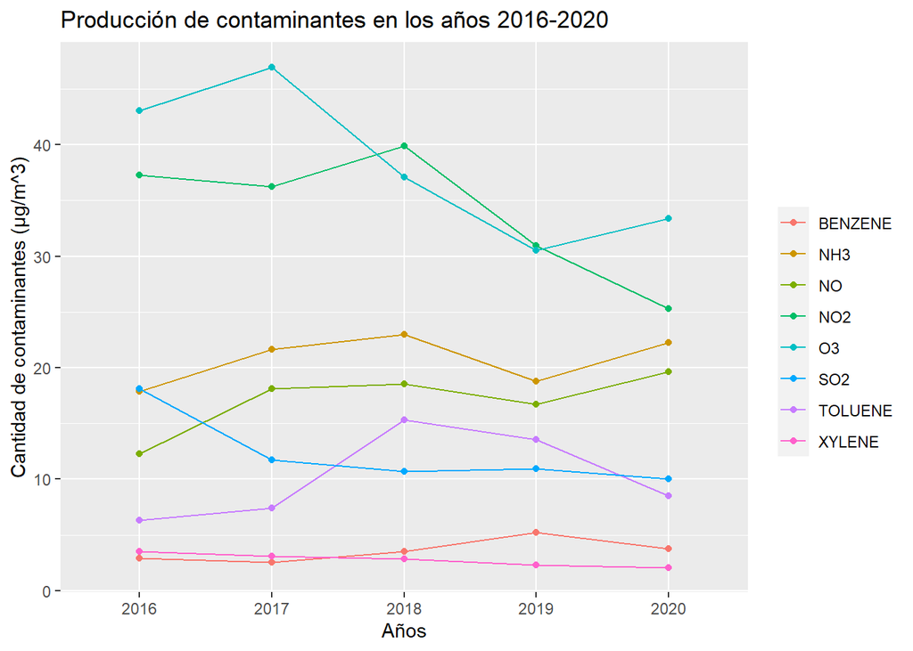

```r
library(ggplot2)
ggplot(data=tot_conta,mapping = aes(x=Anios))+geom_line(mapping = aes(y=TOLUENE,color="TOLUENE"),group=1)+geom_point(mapping = aes(y=TOLUENE,color="TOLUENE"))+geom_line(mapping = aes(y=NO,color="NO"),group=1)+geom_point(mapping = aes(y=NO,color="NO"))+geom_line(mapping = aes(y=NO2,color="NO2"),group=1)+geom_point(mapping = aes(y=NO2,color="NO2"))+geom_line(mapping = aes(y=NH3,color="NH3"),group=1)+geom_point(mapping = aes(y=NH3,color="NH3"))+geom_line(mapping = aes(y=SO2,color="SO2"),group=1)+geom_point(mapping = aes(y=SO2,color="SO2"))+geom_line(mapping = aes(y=O3,color="O3"),group=1)+geom_point(mapping = aes(y=O3,color="O3"))+geom_line(mapping = aes(y=BENZENE,color="BENZENE"),group=1)+geom_point(mapping = aes(y=BENZENE,color="BENZENE"))+geom_line(mapping = aes(y=XYLENE,color="XYLENE"),group=1)+geom_point(mapping = aes(y=XYLENE,color="XYLENE"))+
  ggtitle("Producción de contaminantes en los años 2016-2020") +
    labs(y= "Cantidad de contaminantes (µg/m^3)", x="Años", color="")
```

#### Cantidad totales de contaminantes, bigotes ver la variación y datos atípicos

```r
C_T <- DFCH1 %>% group_by(Year) %>% summarise(City,ST)
C_T <-C_T %>% filter(Year==c("2016","2017","2018","2019","2020"))
C_T_1 <- C_T %>% group_by(Year) %>% summarise(ST)
```

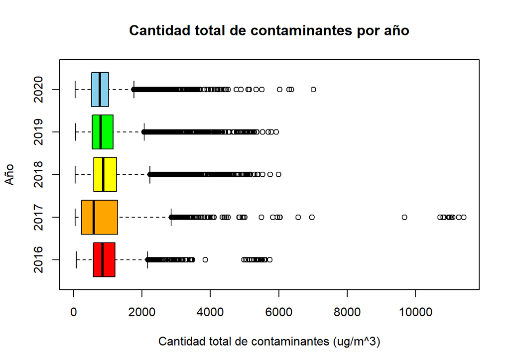

```r
C_T_1 <- C_T_1[-which.max(C_T_1$ST),]

boxplot(ST ~ Year,data=C_T_1,ylab="Año",xlab="Cantidad total de contaminantes (ug/m^3)",main="Cantidad total de contaminantes por año",horizontal = T,col=c("red","orange","yellow","green","skyblue","pink"))
```

#### Cantidad de AQI mensual

Observación: De la gráfica podemos observar que los meses en los cuales se presenta un mayor AQI son entre noviembre y febrero.

Hipótesis: Entre esos meses es la época de invierno en India, en la cual aumenta el uso de automóviles y se realiza la quema de los cultivos que no pudieron resistir el clima frío. Asimismo, en el mes de noviembre se celebra el Diwali, donde suelen prender fuegos artificiales. Esto genera el aumento de gases contaminantes.

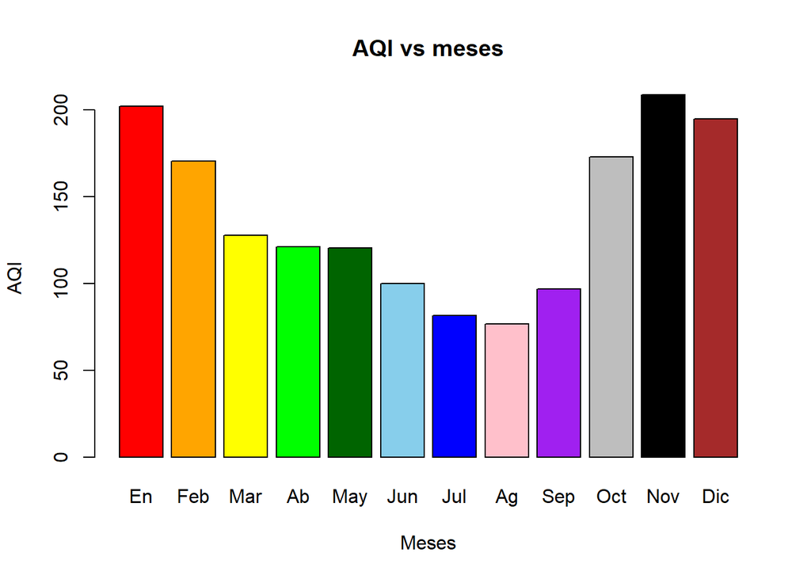

```r
M1<-DFCH1  %>% filter(Month=="01")%>% summarise(mean(AQI))
M2<-DFCH1 %>% filter(Month=="02")%>% summarise(mean(AQI))
M3<-DFCH1 %>% filter(Month=="03")%>% summarise(mean(AQI))
M4<-DFCH1 %>% filter(Month=="04")%>% summarise(mean(AQI))
M5<-DFCH1 %>% filter(Month=="05")%>% summarise(mean(AQI))
M6<-DFCH1 %>% filter(Month=="06")%>% summarise(mean(AQI))
M7<-DFCH1 %>% filter(Month=="07")%>% summarise(mean(AQI))
M8<-DFCH1 %>% filter(Month=="08")%>% summarise(mean(AQI))
M9<-DFCH1 %>% filter(Month=="09")%>% summarise(mean(AQI))
M10<-DFCH1 %>% filter(Month=="10")%>% summarise(mean(AQI))
M11<-DFCH1 %>% filter(Month=="11")%>% summarise(mean(AQI))
M12<-DFCH1 %>% filter(Month=="12")%>% summarise(mean(AQI))

AQI_M<-c("En","Feb","Mar","Ab","May","Jun","Jul","Ag","Sep","Oct","Nov","Dic")
AQI_C<-c(M1$`mean(AQI)`,M2$`mean(AQI)`,M3$`mean(AQI)`,M4$`mean(AQI)`,M5$`mean(AQI)`,M6$`mean(AQI)`,M7$`mean(AQI)`,M8$`mean(AQI)`,M9$`mean(AQI)`,M10$`mean(AQI)`,M11$`mean(AQI)`,M12$`mean(AQI)`)

MxC<-data.frame(AQI_M,AQI_C)

barplot(MxC$AQI_C,names.arg =MxC$AQI_M, main="AQI vs meses",col=c("red","orange","yellow","green","darkgreen","skyblue","blue","pink","purple","grey","black","brown"),xlab="Meses",ylab="AQI")
```

#### Cantidad de AQI mensual por años

Entre los años 2016 y 2019 se mantiene que entre los meses de noviembre y febrero se presenta la mayor cantidad de AQI. En 2015 se muestra un mayor de AQI porque ocurrió un golpe calor que hizo que se intensificara la emisión de gases contaminantes. En 2020 se muestra una disminución de AQI porque el confinamiento ocurrió aproximadamente en marzo de ese año, por lo que disminuyó la emisión de gases contaminantes.

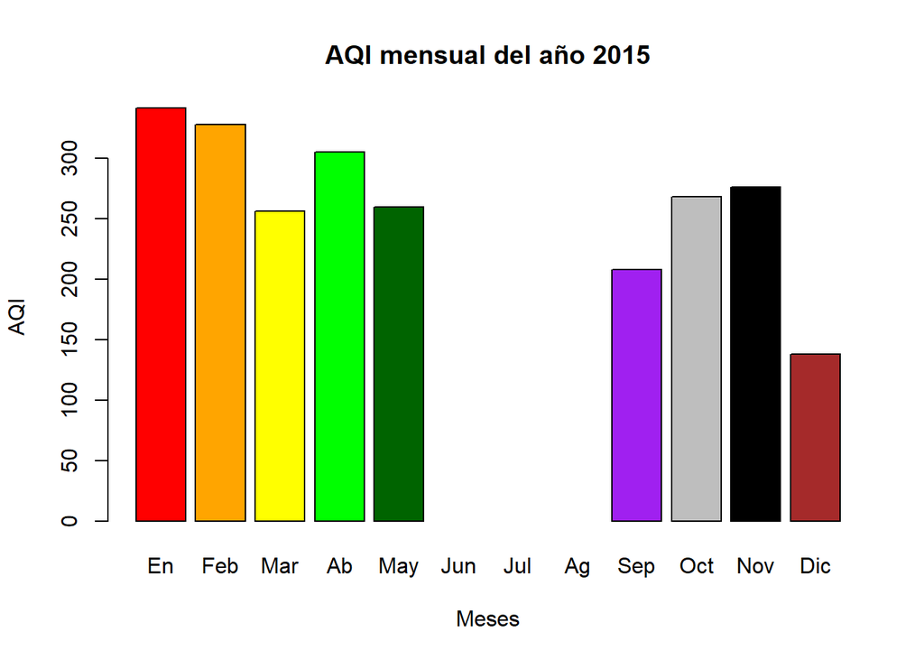

```r
#2015
A2015<-DFCH1 %>% filter(Year==2015)
A1_15<-A2015  %>% filter(Month=="01")%>% summarise(mean(AQI))
A2_15<-A2015 %>% filter(Month=="02")%>% summarise(mean(AQI))
A3_15<-A2015 %>% filter(Month=="03")%>% summarise(mean(AQI))
A4_15<-A2015 %>% filter(Month=="04")%>% summarise(mean(AQI))
A5_15<-A2015 %>% filter(Month=="05")%>% summarise(mean(AQI))
A6_15<-A2015 %>% filter(Month=="06")%>% summarise(mean(AQI))
A7_15<-A2015 %>% filter(Month=="07")%>% summarise(mean(AQI))
A8_15<-A2015 %>% filter(Month=="08")%>% summarise(mean(AQI))
A9_15<-A2015 %>% filter(Month=="09")%>% summarise(mean(AQI))
A10_15<-A2015 %>% filter(Month=="10")%>% summarise(mean(AQI))
A11_15<-A2015 %>% filter(Month=="11")%>% summarise(mean(AQI))
A12_15<-A2015 %>% filter(Month=="12")%>% summarise(mean(AQI))

AQI_M<-c("En","Feb","Mar","Ab","May","Jun","Jul","Ag","Sep","Oct","Nov","Dic")

AQI_C15<-c(A1_15$`mean(AQI)`,A2_15$`mean(AQI)`,A3_15$`mean(AQI)`,A4_15$`mean(AQI)`,A5_15$`mean(AQI)`,A6_15$`mean(AQI)`,A7_15$`mean(AQI)`,A8_15$`mean(AQI)`,A9_15$`mean(AQI)`,A10_15$`mean(AQI)`,A11_15$`mean(AQI)`,A12_15$`mean(AQI)`)

MxC_15<-data.frame(AQI_M,AQI_C15)

barplot(MxC_15$AQI_C,names.arg =MxC_15$AQI_M, main="AQI mensual del año 2015",col=c("red","orange","yellow","green","darkgreen","skyblue","blue","pink","purple","grey","black","brown"),xlab="Meses",ylab="AQI")
```

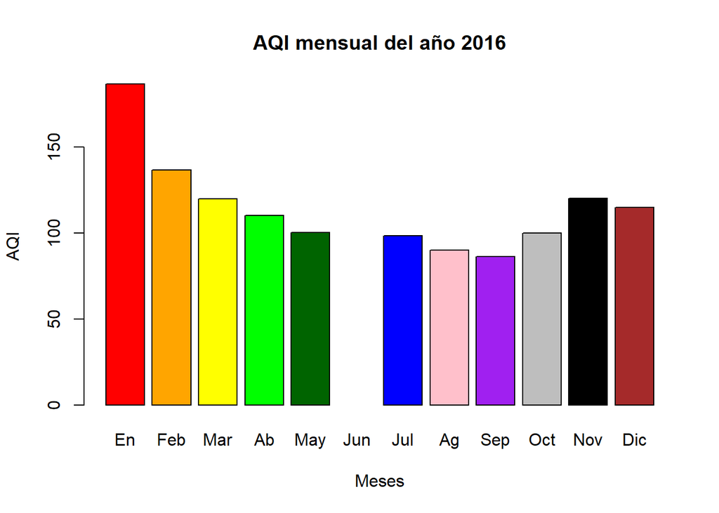

```r
#2016
A2016<-DFCH1 %>% filter(Year==2016)
A1_16<-A2016  %>% filter(Month=="01")%>% summarise(mean(AQI))
A2_16<-A2016  %>% filter(Month=="02")%>% summarise(mean(AQI))
A3_16<-A2016  %>% filter(Month=="03")%>% summarise(mean(AQI))
A4_16<-A2016  %>% filter(Month=="04")%>% summarise(mean(AQI))
A5_16<-A2016 %>% filter(Month=="05")%>% summarise(mean(AQI))
A6_16<-A2016  %>% filter(Month=="06")%>% summarise(mean(AQI))
A7_16<-A2016  %>% filter(Month=="07")%>% summarise(mean(AQI))
A8_16<-A2016  %>% filter(Month=="08")%>% summarise(mean(AQI))
A9_16<-A2016  %>% filter(Month=="09")%>% summarise(mean(AQI))
A10_16<-A2016  %>% filter(Month=="10")%>% summarise(mean(AQI))
A11_16<-A2016  %>% filter(Month=="11")%>% summarise(mean(AQI))
A12_16<-A2016  %>% filter(Month=="12")%>% summarise(mean(AQI))


AQI_C16<-c(A1_16$`mean(AQI)`,A2_16$`mean(AQI)`,A3_16$`mean(AQI)`,A4_16$`mean(AQI)`,A5_16$`mean(AQI)`,A6_16$`mean(AQI)`,A7_16$`mean(AQI)`,A8_16$`mean(AQI)`,A9_16$`mean(AQI)`,A10_16$`mean(AQI)`,A11_16$`mean(AQI)`,A12_16$`mean(AQI)`)

MxC_16<-data.frame(AQI_M,AQI_C16)

barplot(MxC_16$AQI_C,names.arg =MxC_16$AQI_M, main="AQI mensual del año 2016",col=c("red","orange","yellow","green","darkgreen","skyblue","blue","pink","purple","grey","black","brown"),xlab="Meses",ylab="AQI")
```

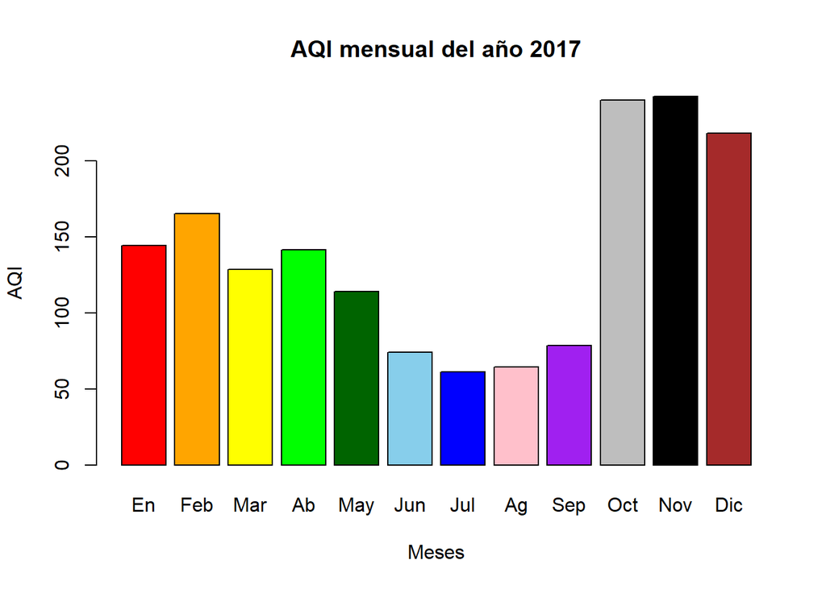

```r
#2017
A2017<-DFCH1 %>% filter(Year==2017)
A1_17<-A2017  %>% filter(Month=="01")%>% summarise(mean(AQI))
A2_17<-A2017  %>% filter(Month=="02")%>% summarise(mean(AQI))
A3_17<-A2017  %>% filter(Month=="03")%>% summarise(mean(AQI))
A4_17<-A2017  %>% filter(Month=="04")%>% summarise(mean(AQI))
A5_17<-A2017 %>% filter(Month=="05")%>% summarise(mean(AQI))
A6_17<-A2017  %>% filter(Month=="06")%>% summarise(mean(AQI))
A7_17<-A2017  %>% filter(Month=="07")%>% summarise(mean(AQI))
A8_17<-A2017  %>% filter(Month=="08")%>% summarise(mean(AQI))
A9_17<-A2017  %>% filter(Month=="09")%>% summarise(mean(AQI))
A10_17<-A2017  %>% filter(Month=="10")%>% summarise(mean(AQI))
A11_17<-A2017  %>% filter(Month=="11")%>% summarise(mean(AQI))
A12_17<-A2017  %>% filter(Month=="12")%>% summarise(mean(AQI))

AQI_C17<-c(A1_17$`mean(AQI)`,A2_17$`mean(AQI)`,A3_17$`mean(AQI)`,A4_17$`mean(AQI)`,A5_17$`mean(AQI)`,A6_17$`mean(AQI)`,A7_17$`mean(AQI)`,A8_17$`mean(AQI)`,A9_17$`mean(AQI)`,A10_17$`mean(AQI)`,A11_17$`mean(AQI)`,A12_17$`mean(AQI)`)

MxC_17<-data.frame(AQI_M,AQI_C17)

barplot(MxC_17$AQI_C,names.arg =MxC_17$AQI_M, main="AQI mensual del año 2017",col=c("red","orange","yellow","green","darkgreen","skyblue","blue","pink","purple","grey","black","brown"),xlab="Meses",ylab="AQI")
```

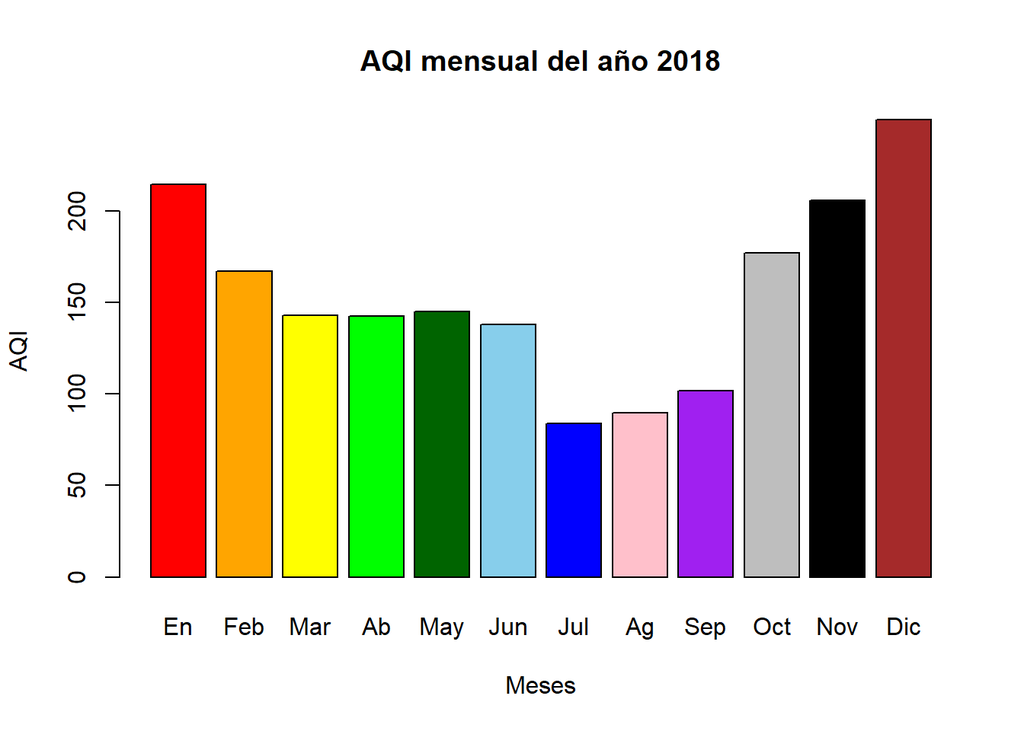

```r
#2018

A2018<-DFCH1 %>% filter(Year==2018)
A1_18<-A2018  %>% filter(Month=="01")%>% summarise(mean(AQI))
A2_18<-A2018  %>% filter(Month=="02")%>% summarise(mean(AQI))
A3_18<-A2018  %>% filter(Month=="03")%>% summarise(mean(AQI))
A4_18<-A2018  %>% filter(Month=="04")%>% summarise(mean(AQI))
A5_18<-A2018 %>% filter(Month=="05")%>% summarise(mean(AQI))
A6_18<-A2018  %>% filter(Month=="06")%>% summarise(mean(AQI))
A7_18<-A2018  %>% filter(Month=="07")%>% summarise(mean(AQI))
A8_18<-A2018  %>% filter(Month=="08")%>% summarise(mean(AQI))
A9_18<-A2018  %>% filter(Month=="09")%>% summarise(mean(AQI))
A10_18<-A2018  %>% filter(Month=="10")%>% summarise(mean(AQI))
A11_18<-A2018  %>% filter(Month=="11")%>% summarise(mean(AQI))
A12_18<-A2018  %>% filter(Month=="12")%>% summarise(mean(AQI))

AQI_C18<-c(A1_18$`mean(AQI)`,A2_18$`mean(AQI)`,A3_18$`mean(AQI)`,A4_18$`mean(AQI)`,A5_18$`mean(AQI)`,A6_18$`mean(AQI)`,A7_18$`mean(AQI)`,A8_18$`mean(AQI)`,A9_18$`mean(AQI)`,A10_18$`mean(AQI)`,A11_18$`mean(AQI)`,A12_18$`mean(AQI)`)

MxC_18<-data.frame(AQI_M,AQI_C18)

barplot(MxC_18$AQI_C,names.arg =MxC_18$AQI_M, main="AQI mensual del año 2018",col=c("red","orange","yellow","green","darkgreen","skyblue","blue","pink","purple","grey","black","brown"),xlab="Meses",ylab="AQI")
```

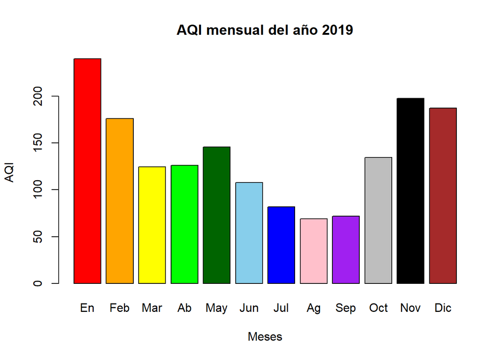

```r
#2019
A2019<-DFCH1 %>% filter(Year==2019)
A1_19<-A2019  %>% filter(Month=="01")%>% summarise(mean(AQI))
A2_19<-A2019  %>% filter(Month=="02")%>% summarise(mean(AQI))
A3_19<-A2019  %>% filter(Month=="03")%>% summarise(mean(AQI))
A4_19<-A2019  %>% filter(Month=="04")%>% summarise(mean(AQI))
A5_19<-A2019 %>% filter(Month=="05")%>% summarise(mean(AQI))
A6_19<-A2019  %>% filter(Month=="06")%>% summarise(mean(AQI))
A7_19<-A2019  %>% filter(Month=="07")%>% summarise(mean(AQI))
A8_19<-A2019  %>% filter(Month=="08")%>% summarise(mean(AQI))
A9_19<-A2019  %>% filter(Month=="09")%>% summarise(mean(AQI))
A10_19<-A2019  %>% filter(Month=="10")%>% summarise(mean(AQI))
A11_19<-A2019  %>% filter(Month=="11")%>% summarise(mean(AQI))
A12_19<-A2019  %>% filter(Month=="12")%>% summarise(mean(AQI))

AQI_C19<-c(A1_19$`mean(AQI)`,A2_19$`mean(AQI)`,A3_19$`mean(AQI)`,A4_19$`mean(AQI)`,A5_19$`mean(AQI)`,A6_19$`mean(AQI)`,A7_19$`mean(AQI)`,A8_19$`mean(AQI)`,A9_19$`mean(AQI)`,A10_19$`mean(AQI)`,A11_19$`mean(AQI)`,A12_19$`mean(AQI)`)

MxC_19<-data.frame(AQI_M,AQI_C19)

barplot(MxC_19$AQI_C,names.arg =MxC_19$AQI_M, main="AQI mensual del año 2019",col=c("red","orange","yellow","green","darkgreen","skyblue","blue","pink","purple","grey","black","brown"),xlab="Meses",ylab="AQI")
```

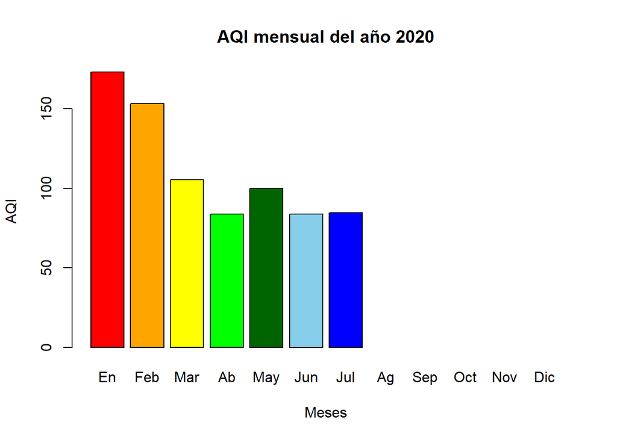

```r
#2020
A2020<-DFCH1 %>% filter(Year==2020)
A1_20<-A2020  %>% filter(Month=="01")%>% summarise(mean(AQI))
A2_20<-A2020  %>% filter(Month=="02")%>% summarise(mean(AQI))
A3_20<-A2020  %>% filter(Month=="03")%>% summarise(mean(AQI))
A4_20<-A2020  %>% filter(Month=="04")%>% summarise(mean(AQI))
A5_20<-A2020 %>% filter(Month=="05")%>% summarise(mean(AQI))
A6_20<-A2020  %>% filter(Month=="06")%>% summarise(mean(AQI))
A7_20<-A2020  %>% filter(Month=="07")%>% summarise(mean(AQI))
A8_20<-A2020  %>% filter(Month=="08")%>% summarise(mean(AQI))
A9_20<-A2020  %>% filter(Month=="09")%>% summarise(mean(AQI))
A10_20<-A2020  %>% filter(Month=="10")%>% summarise(mean(AQI))
A11_20<-A2020  %>% filter(Month=="11")%>% summarise(mean(AQI))
A12_20<-A2020  %>% filter(Month=="12")%>% summarise(mean(AQI))


AQI_C20<-c(A1_20$`mean(AQI)`,A2_20$`mean(AQI)`,A3_20$`mean(AQI)`,A4_20$`mean(AQI)`,A5_20$`mean(AQI)`,A6_20$`mean(AQI)`,A7_20$`mean(AQI)`,A8_20$`mean(AQI)`,A9_20$`mean(AQI)`,A10_20$`mean(AQI)`,A11_20$`mean(AQI)`,A12_20$`mean(AQI)`)

MxC_20<-data.frame(AQI_M,AQI_C20)

barplot(MxC_20$AQI_C,names.arg =MxC_20$AQI_M, main="AQI mensual del año 2020",col=c("red","orange","yellow","green","darkgreen","skyblue","blue","pink","purple","grey","black","brown"),xlab="Meses",ylab="AQI")
```

#### Cantidad (%) de AQI bucket por año

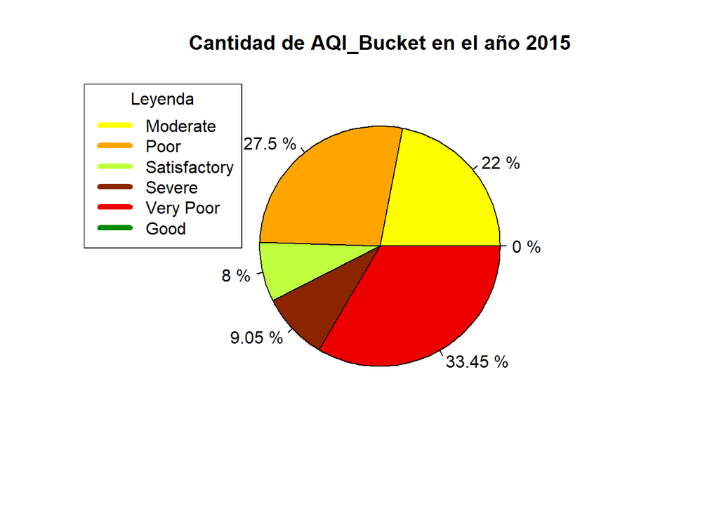

```r
YA<-DFCH1 %>% select(Year,AQI_Bucket)
YA_15<-YA %>% filter(Year==2015)
YA_16<-YA %>% filter(Year==2016)
YA_17<-YA %>% filter(Year==2017)
YA_18<-YA %>% filter(Year==2018)
YA_19<-YA %>% filter(Year==2019)
YA_20<-YA %>% filter(Year==2020)

YA_15<-data.frame(table(YA_15))
YA_16<-data.frame(table(YA_16))
YA_17<-data.frame(table(YA_17))
YA_18<-data.frame(table(YA_18))
YA_19<-data.frame(table(YA_19))
YA_20<-data.frame(table(YA_20))

YA_15<-YA_15 %>% mutate(Cantidad=round(Freq/sum(Freq)*100,2))%>%select(-Freq)
YA_16<-YA_16 %>% mutate(Cantidad=round(Freq/sum(Freq)*100,2))%>%select(-Freq)
YA_17<-YA_17 %>% mutate(Cantidad=round(Freq/sum(Freq)*100,2))%>%select(-Freq)
YA_18<-YA_18 %>% mutate(Cantidad=round(Freq/sum(Freq)*100,2))%>%select(-Freq)
YA_19<-YA_19 %>% mutate(Cantidad=round(Freq/sum(Freq)*100,2))%>%select(-Freq)
YA_20<-YA_20 %>% mutate(Cantidad=round(Freq/sum(Freq)*100,2))%>%select(-Freq)

#Agregando una fila a YA_15
F1<-data.frame("2015","Good",0)
F1<-F1%>% rename("Year"="X.2015.","AQI_Bucket"="X.Good.","Cantidad"="X0")
YA_15<-rbind(YA_15,F1)

Y_15<-c(YA_15$Cantidad)
Y_16<-c(YA_16$Cantidad)
Y_17<-c(YA_17$Cantidad)
Y_18<-c(YA_18$Cantidad)
Y_19<-c(YA_19$Cantidad)
Y_20<-c(YA_20$Cantidad)

DF1<-data.frame(YA_15$AQI_Bucket,Y_15,Y_16,Y_17,Y_18,Y_19,Y_20)

#Para cada año
#2015
p15=c(DF1$Y_15)
etiq15<-paste(p15,"%",sep=" ")

pie(p15,labels=etiq15,col=c("yellow","orange","olivedrab1","orangered4","red2"),main="Cantidad de AQI_Bucket en el año 2015")
legend(x = "topleft", legend = c("Moderate","Poor","Satisfactory","Severe","Very Poor","Good"), title = "Leyenda",col=c("yellow","orange","olivedrab1","orangered4","red2","green4"),lwd = 5)
```

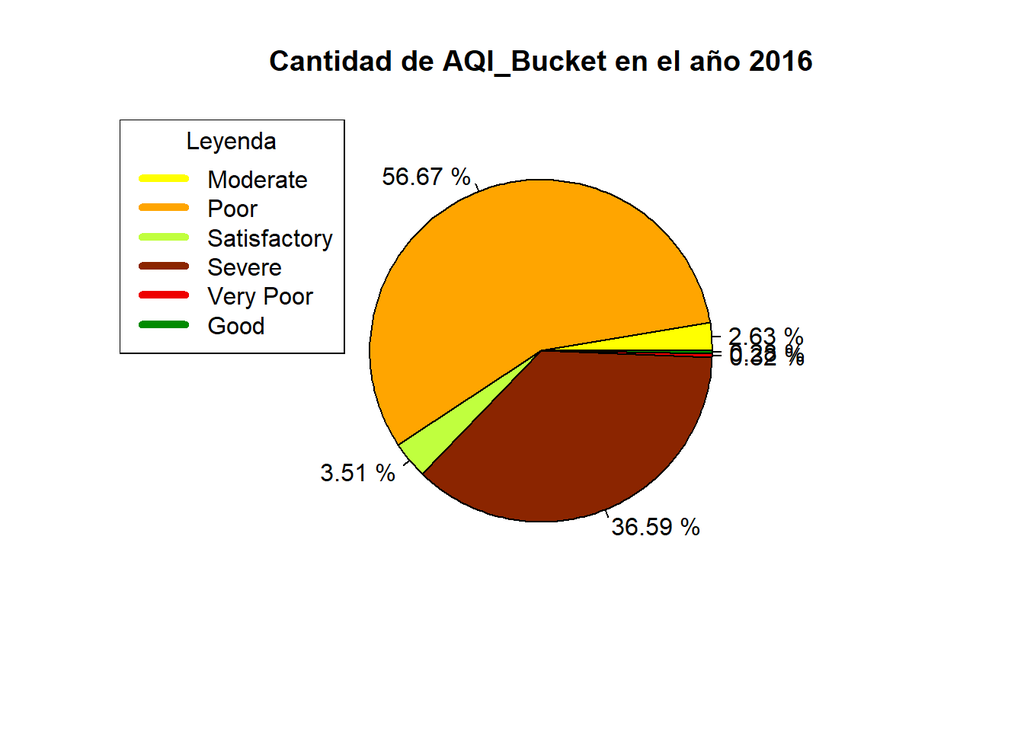

```r
#2016
p16=c(DF1$Y_16)
etiq16<-paste(p16,"%",sep=" ")
pie(p16,labels=etiq16,col=c("yellow","orange","olivedrab1","orangered4","red2","green4"),main="Cantidad de AQI_Bucket en el año 2016")
legend(x = "topleft", legend = c("Moderate","Poor","Satisfactory","Severe","Very Poor","Good"), title = "Leyenda",col=c("yellow","orange","olivedrab1","orangered4","red2","green4"),lwd = 5)
```

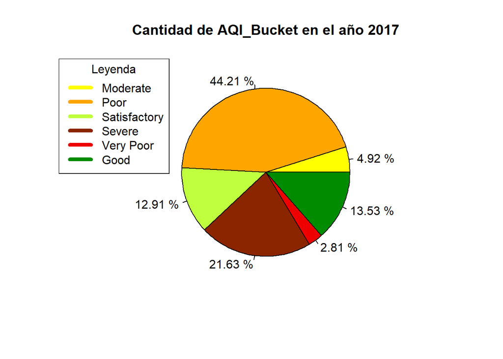

```r
#2017
p17=c(DF1$Y_17)
etiq17<-paste(p17,"%",sep=" ")
pie(p17,labels=etiq17,col=c("yellow","orange","olivedrab1","orangered4","red2","green4"),main="Cantidad de AQI_Bucket en el año 2017")
legend(x = "topleft", legend = c("Moderate","Poor","Satisfactory","Severe","Very Poor","Good"), title = "Leyenda",col=c("yellow","orange","olivedrab1","orangered4","red2","green4"),lwd = 5)
```

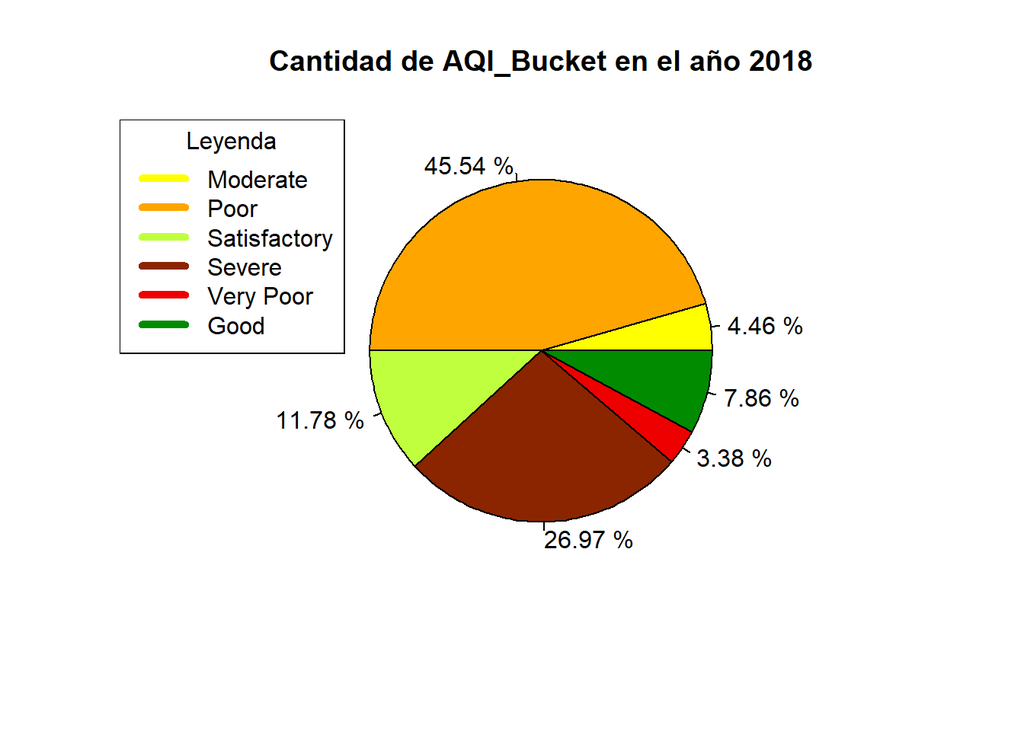

```r
#2018
p18=c(DF1$Y_18)
etiq18<-paste(p18,"%",sep=" ")
pie(p18,labels=etiq18,col=c("yellow","orange","olivedrab1","orangered4","red2","green4"),main="Cantidad de AQI_Bucket en el año 2018")
legend(x = "topleft", legend = c("Moderate","Poor","Satisfactory","Severe","Very Poor","Good"), title = "Leyenda",col=c("yellow","orange","olivedrab1","orangered4","red2","green4"),lwd = 5)
```

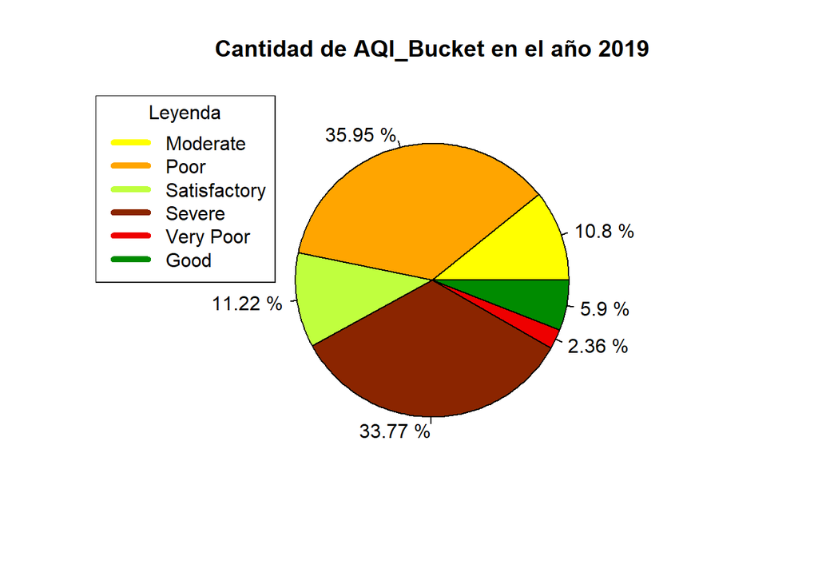

```r
#2019
p19=c(DF1$Y_19)
etiq19<-paste(p19,"%",sep=" ")
pie(p19,labels=etiq19,col=c("yellow","orange","olivedrab1","orangered4","red2","green4"),main="Cantidad de AQI_Bucket en el año 2019")
legend(x = "topleft", legend = c("Moderate","Poor","Satisfactory","Severe","Very Poor","Good"), title = "Leyenda",col=c("yellow","orange","olivedrab1","orangered4","red2","green4"),lwd = 5)
```

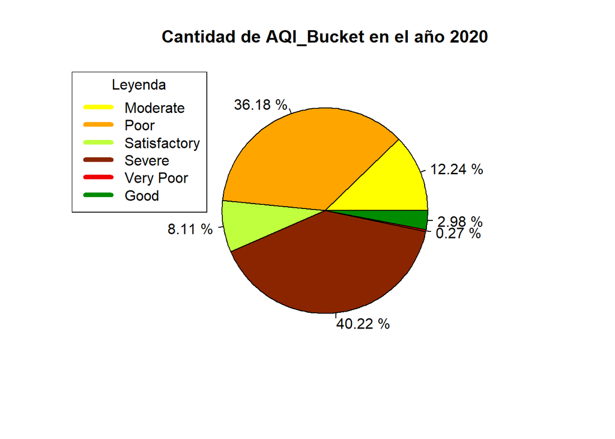

```r
#2020
p20=c(DF1$Y_20)
etiq20<-paste(p20,"%",sep=" ")
pie(p20,labels=etiq20,col=c("yellow","orange","olivedrab1","orangered4","red2","green4"),main="Cantidad de AQI_Bucket en el año 2020")
legend(x = "topleft", legend = c("Moderate","Poor","Satisfactory","Severe","Very Poor","Good"), title = "Leyenda",col=c("yellow","orange","olivedrab1","orangered4","red2","green4"),lwd = 5)
```

Hipótesis: En el año 2020, debido a la cantidad de contaminantes en los primeros meses, los cuales son mayores en todos los años debido a las festividades, el porcentaje del AQI_Bucket se ve incrementado. Además, el confinamiento por COVID-19 en India inició en marzo-2020 por lo que a partir de ese mes que la cantidad de contaminantes reduce.

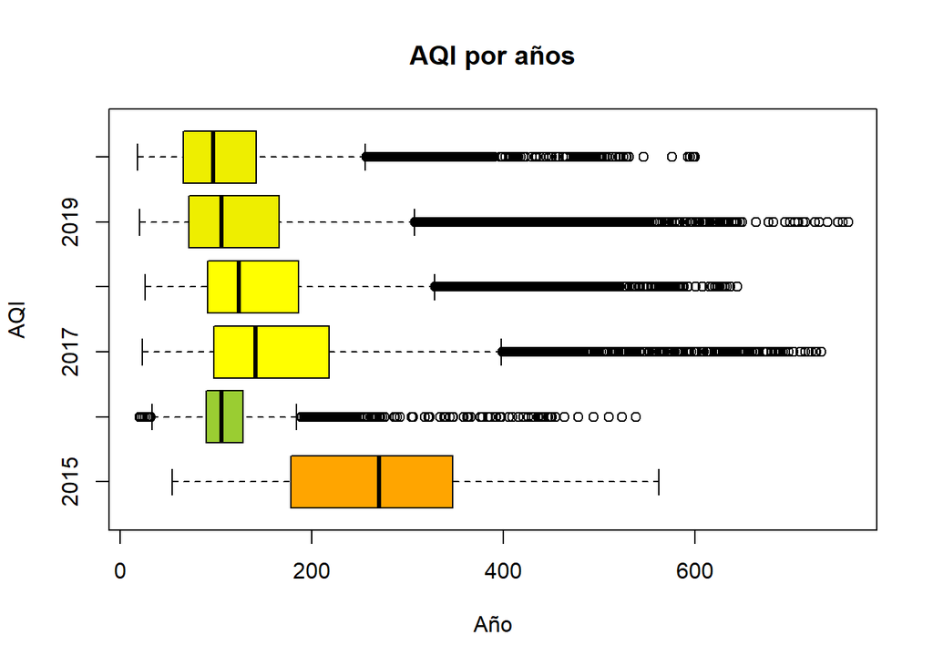

```r
#Cantidad totales de contaminanteS por AÑO por AQI
DFCH1$Year<- as.factor(DFCH1$Year)
plot(x=DFCH1$Year, y=DFCH1$AQI, main="AQI por años",xlab="Año", ylab="AQI",col = c("orange", "yellowgreen", "yellow", "yellow1","yellow2","yellow2"),horizontal=T)
```

```r
#BIGOTES por CIUDADES AQI
DFCH1$City<-as.factor(DFCH1$City)
str(DFCH1$City)
```

```
##  Factor w/ 9 levels "Amaravati","Amritsar",..: 1 1 1 1 1 1 1 1 1 1 ...
```

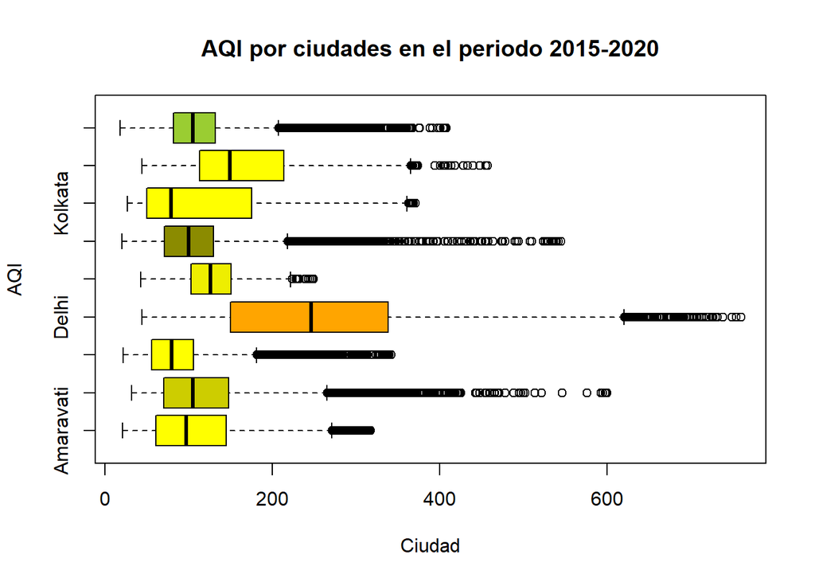

```r
plot(x=DFCH1$City, y=DFCH1$AQI,main="AQI por ciudades en el periodo 2015-2020",xlab="Ciudad", ylab="AQI", col = c("yellow", "yellow3", "yellow", "orange","yellow2", "yellow4", "yellow","yellow1","yellowgreen"),horizontal=T)
```

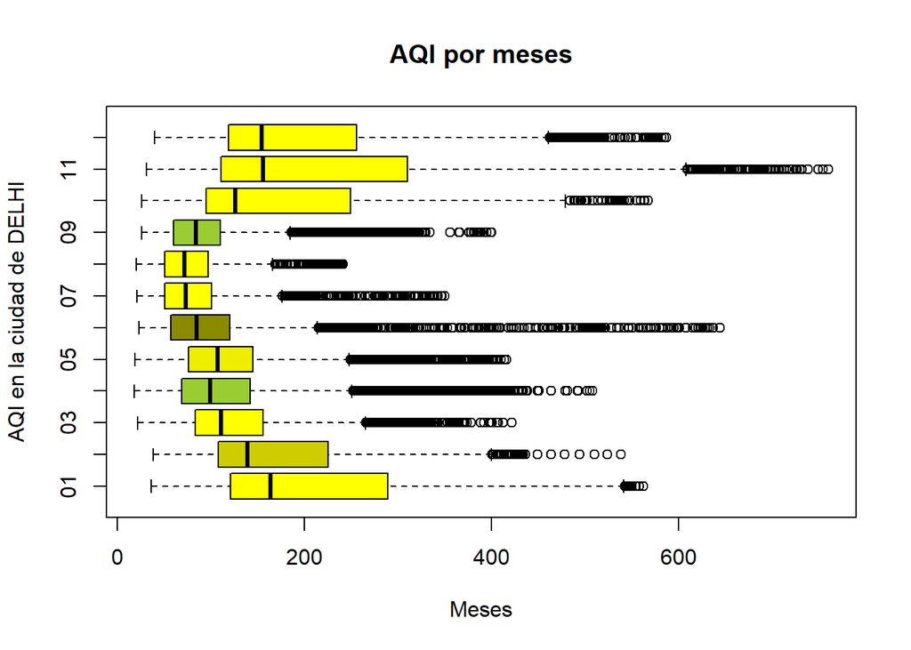

```r
#Bigotes por meses
DFCH1$Month<-as.factor(DFCH1$Month)
plot(x=DFCH1$Month, y=DFCH1$AQI, main="AQI por meses",xlab="Meses", ylab="AQI en la ciudad de DELHI",col = c("yellow", "yellow3", "yellow", "yellowgreen","yellow2", "yellow4", "yellow","yellow1","yellowgreen","yellow","yellow"),horizontal=T)
```

### Correlación entre variables numéricas

Vemos un patrón de correlación entre las variables PM10 y PM2.5 con AQI. Esto debido a que todas estas son un conjunto de sustancias que cumplen con condiciones como: medir un diámetro menor a 2.5 micras o 10 micras. Por tanto, si hay un incremento de sustancias habrá un incremento de PM2.5 o PM10 y también del AQI ya que este último es un indicador de contaminación.

```r
#CORRELACION ENTRE VARIABLES NUMERICAS

PARACOR<-DFCH1%>%select(PM2.5, PM10, AQI)
cor(PARACOR)
```

```
##           PM2.5      PM10       AQI
## PM2.5 1.0000000 0.8626023 0.8136211
## PM10  0.8626023 1.0000000 0.8105313
## AQI   0.8136211 0.8105313 1.0000000
```

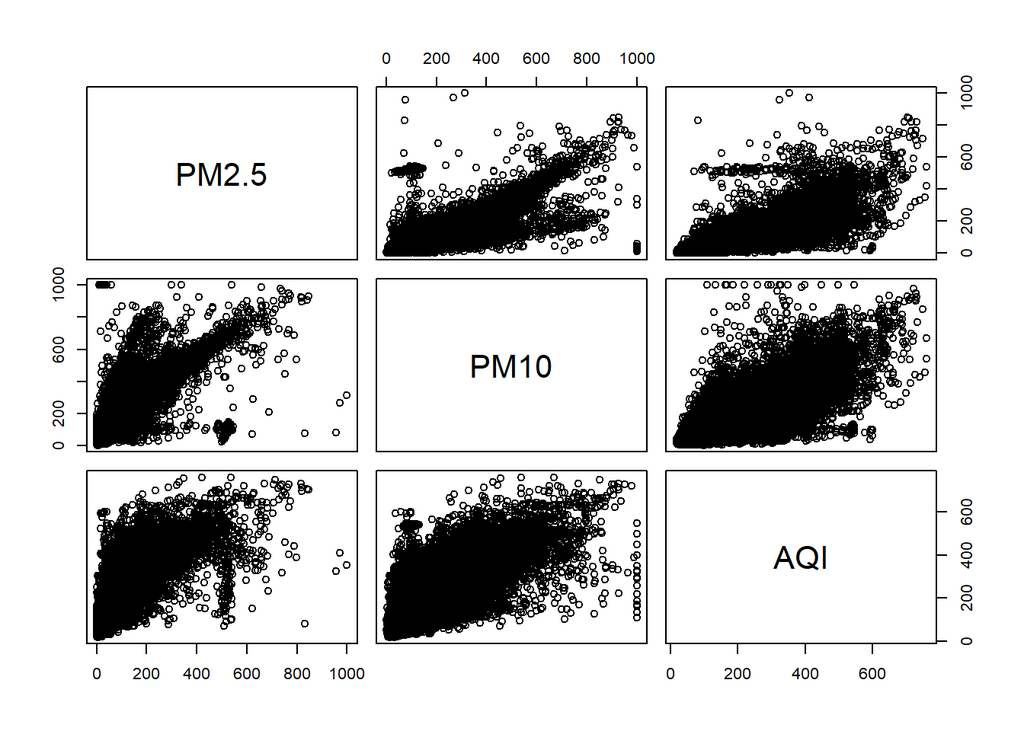

```r
pairs(PARACOR)
```

## Distribución para las variables en estudio

## Gráfica para PM2.5

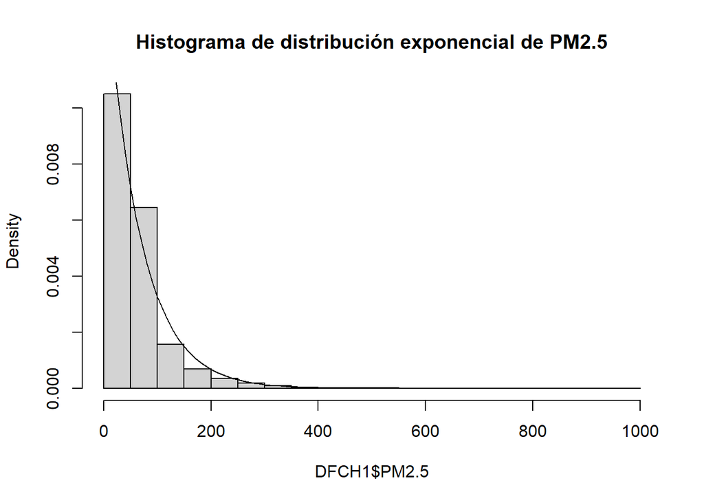

## Gráfica para NO

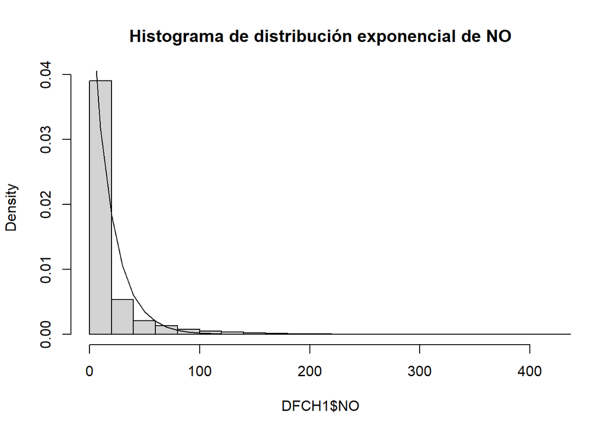

## Gráfica para SO2

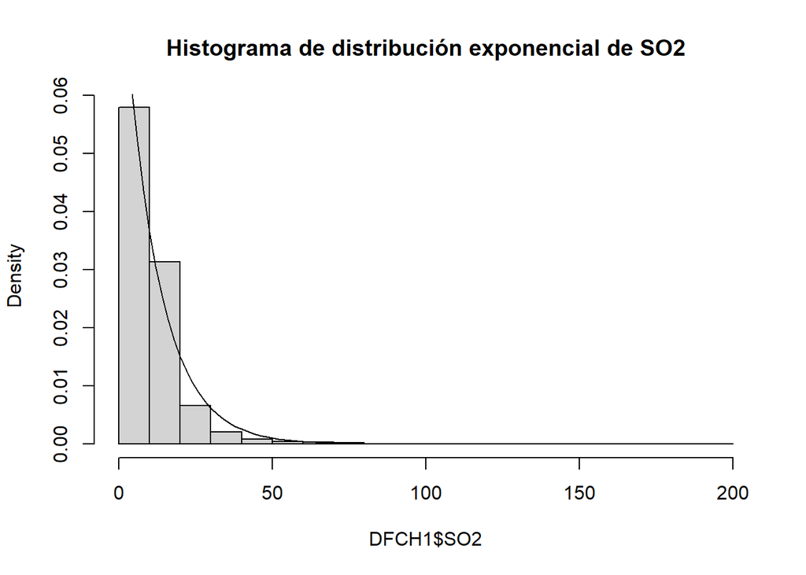

## Gráfica para CO

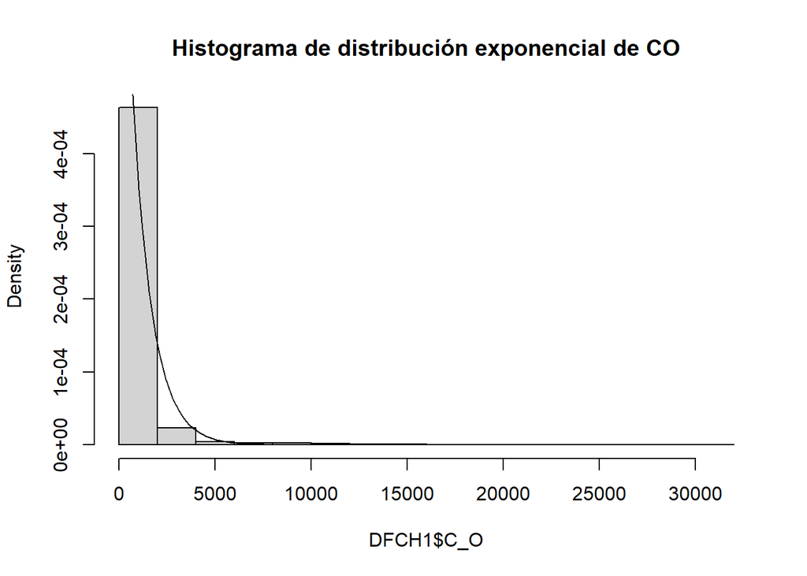

```
## [1] 101909
```

```
## [1] 0
```

```
## [1] NA
```

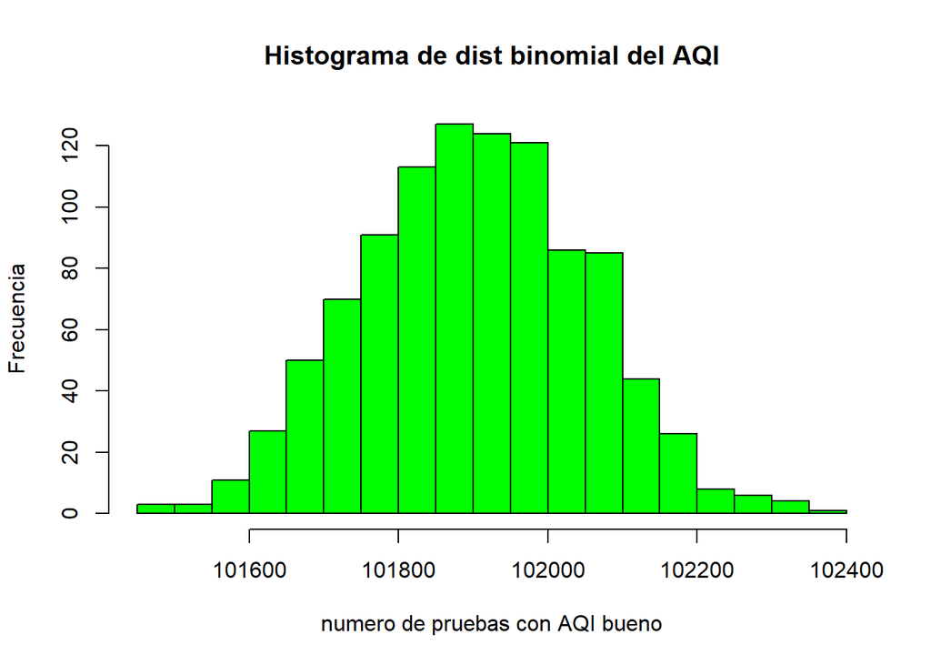

Nivel de confianza: 95% Utilizamos como referencia la guía de calidad de aire de la OMS en donde usan un nivel de confianza del 95%, lo cual indica que dentro del rango dado se encuentra el valor real de un parámetro con 95% de certeza para un tamaño de muestra suficientemente grande.

# Prueba de hipotésis

Función para hallar el estadístico de prueba

```r
estadistico =function (xbarra,s,n,u){
  est=(xbarra-u)/(s/n^0.5)
  return (est)
}
```

Función para hallar el intervalo de confianza para medias

```r
int_conf =function (xbarra,s,t,n){
  a=round(xbarra-t*(s/(n^0.5)),2)
  b=round(xbarra+t*(s/(n^0.5)),2)
  return (c(a,b))
}
```

Hipótesis: La cantidad promedio de PM2.5 anual es mayor a 10 ug/m3.

Pregunta: ¿La cantidad promedio de PM2.5 anual sobrepasa el límite permisible de 10 ug/m3?

## Prueba de hipótesis sobre PM2.5 entre los años 2017-2019

$$H_0:µ<=10$$

$$H_1:µ>10$$

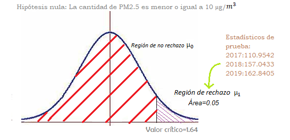

## Año 2017

```r
DF17 <- DFCH1 %>% filter(Year=='2017')
DF18 <- DFCH1 %>% filter(Year=='2018')
DF19 <- DFCH1 %>% filter(Year=='2019')

xbarra_PM2.5_17 = mean(DF17$PM2.5)
s_PM2.5_17 = sd(DF17$PM2.5)
alpha = 0.05
n_17 = nrow(DF17)
valor_critico_17 = qt(1-alpha,n_17-1)
est_PM2.5_17 = estadistico(xbarra_PM2.5_17,s_PM2.5_17,n_17,10)

valor_critico_17
```

```
## [1] 1.644954
```

```r
est_PM2.5_17
```

```
## [1] 110.9542
```

```r
range(DF17$PM2.5)
```

```
## [1]   0.20 999.99
```

```r
int_conf(xbarra_PM2.5_17,s_PM2.5_17,valor_critico_17,n_17)
```

```
## [1] 78.15 80.20
```

$$[78.15,80.20]$$

## Año 2018

```r
xbarra_PM2.5_18 = mean(DF18$PM2.5)
s_PM2.5_18 = sd(DF18$PM2.5)
n_18 = nrow(DF18)
valor_critico_18 = qt(1-alpha,n_18-1)
est_PM2.5_18 = estadistico(xbarra_PM2.5_18,s_PM2.5_18,n_18,10)

valor_critico_18
```

```
## [1] 1.644908
```

```r
est_PM2.5_18
```

```
## [1] 157.0433
```

```r
range(DF18$PM2.5)
```

```
## [1]   0.25 830.00
```

```r
int_conf(xbarra_PM2.5_18,s_PM2.5_18,valor_critico_18,n_18)
```

```
## [1] 69.03 70.28
```

$$[69.03,70.28]$$

## Año 2019

```r
xbarra_PM2.5_19 = mean(DF19$PM2.5)
s_PM2.5_19 = sd(DF19$PM2.5)
n_19 = nrow(DF19)
valor_critico_19 = qt(1-alpha,n_19-1)
est_PM2.5_19 = estadistico(xbarra_PM2.5_19,s_PM2.5_19,n_19,10)

valor_critico_19
```

```
## [1] 1.644893
```

```r
est_PM2.5_19
```

```
## [1] 162.8405
```

```r
range(DF19$PM2.5)
```

```
## [1]   0.25 847.97
```

```r
int_conf(xbarra_PM2.5_19,s_PM2.5_19,valor_critico_19,n_19)
```

```
## [1] 60.16 61.19
```

$$[60.16,61.19]$$

Conclusión: Sí rechazamos H0, porque el estadístico de prueba está en la zona de rechazo. Además, se observa que nuestra media poblacional sobrepasa el límite permisivo anual establecido por la OMS de 10 ug/m3, lo que ocasiona que los habitantes de India corran el riesgo de desarrollar enfermedades cardiovasculares y respiratorias, así como cáncer de pulmón.

Según el informe de la Green Peace: Dato: La cantidad de PM2.5 promedio en Delhi en 2020 fue casi 6 veces superior al límite permisible por la OMS.

Según la publicación médica de The Lancet: Al rededor de 1.67 millones de vidas se perdieron en India por aire tóxico.

Extraído de: https://bit.ly/3hWbkfQ https://reut.rs/3eOLKaI

Hipótesis: La cantidad promedio de PM10 anual es mayor a 20 ug/m3.

Pregunta: ¿La cantidad promedio de PM10 anual sobrepasa el límite permisible de 20 ug/m3?

## Prueba de hipótesis sobre PM10 entre los años 2017-2019

$$H_0:µ<=20$$
$$H_1:µ>20$$

[figure not shown]